# ProbaV

Jorn Dallinga, ProbaV package used from Johannes Eberenz

23 December, 2016

# WUR ProbaV workflow

## Introduction

'the ProbaV instrument

ESA is currently preparing the launch of the Sentinel-3 satellites, of which the first one (Sentinel-3A) is foreseen for September 29tn, 2015. The Sentinel missions are developed for the operational needs in land, ocean, and atmospheric monitoring within the European Copernicus programme. However, between the end-of-life of SPOT-VGT and the launch of the Sentinel-3 satellites, a rather large time gap of about 3 years would occur, which would imply a discontinuation of the vegetation monitoring time series.

In order to preserve this observational continuity, Belgium decided to build a small satellite mission based on the successful ESA PROBA expertise, using state-of-the-art-technology. ProbaV (with "V" standing for Vegetation) was designed by a full Belgian consortium, fulfills all of the vegetation users specifications and is complement to the Sentinel-3 satellites to be launched after ProbaV.

ProbaV has a constellation of 3 cameras that daily observe the land surface and vegetation at similar spectral wavelengths (BLUE, RED, NIR, and SWIR) as SPOT-VGT, but with an improved spatial resolution (300 m and 100 m for the centre camera). These observations are processed into daily and 10-daily syntheses products, available at 100 m, 300 m, and 1 km. The products can be downloaded from vito'. [source](http://ProbaV.vgt.vito.be/)

## Preperation

This script has been tested and runs on a LINUX Centos machine located on the Mission Exploitation Platform (MEP) from ESA, but might require some tweaking if used on other OS or versions. For more information on the MEP, please follow this [link](https://proba-v-mep.esa.int/node/12). Most functions are designed to run parallel on multi-core machines, such as on the MEP. This example script uses a small case study throughout the tutorial. However, when extending the functions to larger areas, system time could become significantly longer due to slower processing (depending on your computational power at your disposal).

System on which the script has been tested:

```r
## sysname
## "Linux"
## [1] "unix"
## [1] "linux-gnu"
```

The data used within these scripts can be downloaded from the [vito](http://ProbaV.vgt.vito.be/) website. Lets start with loading the required libraries and packages to illustrate a workflow on working with the ProbaV data. Additionally, we have to set the library path if this has not been set previously (This could depend on your MEP machine settings). When working from the MEP, (occasional) errors could occur with loading packages when the library path has not been added.

```r
# add additional libary path
# Depends on which R version you work with
.libPaths( c( .libPaths(), "~/R/x86_64-redhat-linux-gnu-library/3.2") )

## libaries
library(ranger)
library(raster)
library(ggvis)
library(rgdal)
library(dplyr)
library(devtools)
library(gdalUtils)
library(probaV)
library(tools)
library(parallel)
library(zoo)
library(RCurl)
library(stringr)
library(rasterVis)
```

The ProbaV package used can be viewed [here](https://github.com/johanez/ProbaV). Many fixes, including spelling, and further updating of the package is still underway. Furthermore, we download (and source) some adjusted scripts directly using the following 'source_ttps' function from another github repository.

```r
source_https <- function(url, ...) {
  # load package
  require(RCurl)

  # parse and evaluate each .R script
  sapply(c(url, ...), function(u) {
    eval(parse(text = getURL(u, followlocation = TRUE, cainfo = system.file("CurlSSL", "cacert.pem", package = "RCurl"))), envir = .GlobalEnv)
  })
}
source_https("https://raw.githubusercontent.com/JornDallinga/ProbaV_JD/master/R/cloud_filter.R")
```

## Preprocessing

Lets start with the preprocessing of the data. The following sections of the tutorial only work by following the ProbaV directory structure on the ProbaV MEP. The files should be stored in the folder structure used by vito (One folder per date, in YYYYMMDD format, which contains files for all tiles).

The ProbaV has 3 synthesis products, S1 (daily observations), S5 (mosaic-ed 5 day observation) and S10 (mosaic-ed 10 day observation). In the case of a 10-day synthesis product, the product has a minimum effect of cloud cover, resulting from selection of cloud-free acquisitions during the 10-day period. Additionally, their are two products among these daily products available, the Top of Atmosphere (TOA) and Top of Canopy (TOC). The TOC is the atmospheric corrected product, and in combination with the S5 synthesis, is the data we are going to use in this tutorial.

Below the data location of my ProbaV data (l0_dir), and where I intend to store my new data sets (outdir).

start by setting our data path which contains the downloaded files. The following section loops through the downloaded data folder and retrieves the product information, such as tiles and acquisition dates. Since the we only work with .tif files (for now), we add '.tif$' to the pattern selection.

```r
# variable setting for data path
10_dir <- "set data path"
# if you manually downloaded the data
10_dir <- dirloc # Character
# set data path to which you would write large files
outdir <- outdir # Character
```

The files should be stored in the folder structure used by vito, using YYYYMMDD notation for the folders that contain the .tif files. Where one folder per date (YYYYMMDD) contains files for all tiles. Through which folders you wish to loop the product information function, is up to you. For this tutorial, we select a preset of folders based on subfolder directory length. In this scenario, I know that the YYYYMMDD folder notations contain the correct .tif files. Since there are several folders that still contain unprocessed ProbaV data in my 'l0_dir' path, I want to exclude them.

NOTE: If you wish to simply use one folder name as directory(l0_dir), note that all the .tif files in the sub-folders will be selected in the looping process, including folders that might contain incorrect/unprocessed .tif files.

```r
# list files in the main directory that stores the YYYYMMDD folders containing the ProbaV data
lf <- list.files(l0_dir)
# Simple selection of folders based on name length == YYYYMMDD
lf <- lf[nchar(lf) == 8]
# Create coerced subfolder variable which contain all the ProbaV .tif files that you wish to process.
dir_file <- paste0(l0_dir,'/',lf)
```

The dir_file variable now contains all the folders in which we would look for the ProbaV .tif files. The structure of this variable is shown below:

```r
class(dir_file)
```

```r
## [1] "character"
```

```r
head(dir_file)
```

```r
## [1] "/data/MTDA/TIFFDERIVED/PROBAV_L3_S5_TOC_100M/20140311"
## [2] "/data/MTDA/TIFFDERIVED/PROBAV_L3_S5_TOC_100M/20140701"
## [3] "/data/MTDA/TIFFDERIVED/PROBAV_L3_S5_TOC_100M/20140706"
## [4] "/data/MTDA/TIFFDERIVED/PROBAV_L3_S5_TOC_100M/20140711"
## [5] "/data/MTDA/TIFFDERIVED/PROBAV_L3_S5_TOC_100M/20140716"
## [6] "/data/MTDA/TIFFDERIVED/PROBAV_L3_S5_TOC_100M/20140721"
```

Throughout this tutorial, we will work with the tile 'X17Y06', which is located in Africa.

Lets map the extent of the tile:

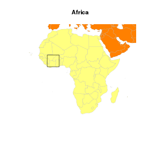

Now lets loop through this directory (dir_file) and collect all the metadata for a specific tile. The selection of dates will be done later.

```r
# create a loop to apply the getProbaVinfo function on a group of folders
datalist = list()
tiles <- 'X17Y06'
for (i in 1:length(dir_file)){
  dat <- getProbaVinfo(dir_file[i], pattern = ".tif$", tiles = tiles)
  datalist[[i]] <- dat # add dat your list
}
# merge the created dataframes into a single dataframe of product information on your selected tiles.
df_ProbaV_down <- do.call(rbind, datalist)
```

## Clean data

The function 'getProbaVQClist' creates a dataframe of state mask (SM) codes based on the quality indicators in the Status Map dataset. It provides an overview of clear codes per channel. Explanation on these SM codes can be found in the [ProbaV Product User Manual](http://ProbaV.vgt.vito.be/sites/default/files/ProbaV-Products_User_Manual_v1.2.pdf), which can also be downloaded directly from the Vito [website](http://www.vito-eodata.be/PDF/portal/Application.html#Home).

For clear pixel selection, we use the SM codes with 'clear_all', which means that a certain pixel is not marked as shadow, cloud, ice or sea. Additionally, it selects only the 'good' quality pixels of the radiometric bands (SWIR, NIR, RED, BLUE).

```r
# Top of dataframe showing SM codes.
head(getProbaVQClist()$all_bits)
```

```r
##   V1 V2 V3 V4 V5 V6 V7 V8 value cloud shadow  sea clear_all clear_noswir
## 1  1  0  0  0  0  0  0  0     1 FALSE   TRUE TRUE     FALSE        FALSE
## 2  0  1  0  0  0  0  0  0     2 FALSE  FALSE TRUE     FALSE        FALSE
## 3  1  1  0  0  0  0  0  0     3  TRUE  FALSE TRUE     FALSE        FALSE
## 4  0  0  1  0  0  0  0  0     4 FALSE  FALSE TRUE     FALSE        FALSE
## 5  1  0  1  0  0  0  0  0     5 FALSE  FALSE TRUE     FALSE        FALSE
## 6  0  1  1  0  0  0  0  0     6 FALSE  FALSE TRUE     FALSE        FALSE
##   clear_r clear_b clear_nir clear_ndvi clear_swir r   g   b
## 1   FALSE   FALSE     FALSE      FALSE      FALSE 0 100 100
## 2   FALSE   FALSE     FALSE      FALSE      FALSE 0 100   0
## 3   FALSE   FALSE     FALSE      FALSE      FALSE 0 100 200
## 4   FALSE   FALSE     FALSE      FALSE      FALSE 0 100   0
## 5   FALSE   FALSE     FALSE      FALSE      FALSE 0 100   0
## 6   FALSE   FALSE     FALSE      FALSE      FALSE 0 100   0
```

```r
# Select quality control value with clear channels
QC_val <- getProbaVQClist()$clear_all
# The QC_val now stores the high quality value:
print(paste('The Quality control value: ',QC_val), sep = "")
```

```r
## [1] "The Quality control value:  248"
```

On the ProbaV-MEP VM, both NDVI and RADIOMETRY .tif files should be stored within the same folder. This can be observed by checking the folder location from which you read your ProbaV data (here 'l0_dir').

The radiometry brick contains 4 raster layers. Lets split the radiometry brick into single .tif layers (SWIR, NIR, RED, BLUE). You can select which tiles you would like to process. In this workflow, we are going to work with 3 bands, the Blue, SWIR and NDVI (NDVI is not part of the radiometry brick) bands. However, the function will extract all the bands that the radiometry brick contains, including the Red and NIR band. This allows you to play around with more band selections.

NOTE: If you wish to work with different bands than within this tutorial, it might require some function tweaking. Feel free to adjust the functions accordingly on the github account (see bottom site).

```r
# First, select the radiometry .tif files from the download folder and which tiles to use
patterns <- c('RADIOMETRY.tif$') # "NDVI.tif$"
tiles <- c("X17Y06") # c("X16Y06","X18Y06", "X19Y06", ...)

# Lets gather the information from the radiometry band using the variables assigned above.
df = list()
for (i in 1:length(dir_file)){
  dat <- getProbaVinfo(dir_file[i], pattern = patterns, tiles = tiles)
  df[[i]] <- dat # add it to your list
}

df <- do.call(rbind, df)
```

Lets have a 'glimpse of our data'. The glimpse function shows the metadata of our dataframe created from the 'getProbaVinfo' function.

```r
# lets get a glimpse of the currently available data in our selection of patterns and tiles.
glimpse(df)
```

```r
## Observations: 68
## Variables: 10
## $ product  "S5_TOC", "S5_TOC", "S5_TOC", "S5_TOC", "S5_TOC", "S5_...
## $ band     "RADIOMETRY", "RADIOMETRY", "RADIOMETRY", "RADIOMETRY"...
## $ X        17, 17, 17, 17, 17, 17, 17, 17, 17, 17, 17, 17, 17, 17...
## $ Y        6, 6, 6, 6, 6, 6, 6, 6, 6, 6, 6, 6, 6, 6, 6, 6, 6, 6, ...
## $ tile     "X17Y06", "X17Y06", "X17Y06", "X17Y06", "X17Y06", "X17...
## $ date     2015-12-21, 2015-12-26, 2016-01-01, 2016-01-06, 2016-...
## $ year     2015, 2015, 2016, 2016, 2016, 2016, 2016, 2016, 2016, ...
## $ yday     354, 359, 0, 5, 10, 15, 20, 25, 31, 36, 41, 46, 51, 56...
## $ fpath    "PROBAV_S5_TOC_20151221_100M_V001/PROBAV_S5_TOC_X17Y06...
## $ fsize    359004466, 414589548, 423599751, 384650203, 403052281,...
```

```r
## [1] "We currently have 68 radiometry bands"
```

Next step is to keep the quality control values in the data which correspond to the QC_val as result of the 'getProbaVQClist' function. Lets test this on a single date/location. Select a RADIOMETRY.tif or NDVI.tif file from the downloaded data folder and assign it to a variable.

```r
# Assign variable from the download location of your Geotiffs. Lets use the NDVI.
# Read a file name from your directory (l0_dir). We will use the tile 'X17Y06' at January 16th, 2016.
r <- paste(l0_dir, "/20160116/PROBAV_S5_TOC_20160116_100M_V001/PROBAV_S5_TOC_X17Y06_20160116_100M_V001_NDVI.tif", sep = "")

# Assign a file.path (including filename) to which we will write the cleaned data.
# Read a file name from your output directory (outdir), following the same date and tile as above.
filename <- paste(outdir,"/PROBAV_S5_TOC_X17Y06_20160116_100M_V001_NDVI_sm.tif", sep = "")
```

```r
cleanProbaV(f_data = r, filename=filename, QC_val = QC_val, fill=255, datatype="FLT4S", as.is = F, overwrite = F)
```

The result is a cleaned raster dataset (right) with only the quality control value (QC_val) selected.

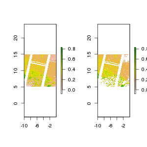

```r
par(mfrow = c(1, 2))
plot(raster(r))
plot(raster(filename))
```

```r
par(mfrow = c(1, 1))
```

## Proccessing a ProbaV batch

The probaV::processProbaVbatch function uses the probaV::cleanProbaV function on a whole 'batch' of data. The starting date parameter helps selecting at which starting point you wish clean the data. The function uses parallel processing, which is useful when the machine has multiple processors or/and cores. The processing time of the following functions thus depend on the process capacity of your machine. In order to process both the radiometry and the NDVI data sets, we will have to run the probaV::processProbaVbatch function twice, with different patterns.

```r
# How many cores do we have:
detectCores(all.tests = FALSE, logical = TRUE)

# Select the patterns to match the .tif files you wish to process.
patterns <- c('RADIOMETRY.tif$') # or "NDVI.tif$"

# similar for pattern = NDVI.tif$
processProbaVbatch(dir_file,
                    pattern = patterns, tiles = tiles, start_date = "2015-10-21",
                    end_date = NULL,
                    QC_val = QC_val, outdir = outdir,
                    ncores = 5,
                    overwrite=F)
```

## Virtual Raster Stack

The following section sets the required parameters for the function 'virtual raster stack'. Most of the parameters are pretty basic, or are repeated here as reminder.

```r
# Select tiles of your study area. Multiple tiles can be coerced together.
tiles <- c("X17Y06") #e.g. c("X17Y06","X18Y06")
```

Lets use the probaV::getProbaVinfo function again to visualize a certain tile data that we have.

```r
# set directory of the processed files as a result of the processProbaVbatch function
ProbaV_sm_dir <- paste(outdir,"/", sep = "")

# lets retrieve information on the available data that we have selected by setting our parameters.
df_ProbaV_sm <- getProbaVinfo(ProbaV_sm_dir, pattern =  '_sm.tif$', tiles = tiles)

# visualize product information, such as bands and acquisition dates.
glimpse(df_ProbaV_sm)
```

```r
## Observations: 544
## Variables: 10
## $ product  "S5_TOC", "S5_TOC", "S5_TOC", "S5_TOC", "S5_TOC", "S5_...
## $ band     "BLUE_sm", "NIR0_sm", "RED0_sm", "SWIR_sm", "BLUE_sm",...
## $ X        17, 17, 17, 17, 17, 17, 17, 17, 17, 17, 17, 17, 17, 17...
## $ Y        6, 6, 6, 6, 6, 6, 6, 6, 6, 6, 6, 6, 6, 6, 6, 6, 6, 6, ...
## $ tile     "X17Y06", "X17Y06", "X17Y06", "X17Y06", "X17Y06", "X17...
## $ date     2014-03-21, 2014-03-21, 2014-03-21, 2014-03-21, 2014-...
## $ year     2014, 2014, 2014, 2014, 2014, 2014, 2014, 2014, 2014, ...
## $ yday     79, 79, 79, 79, 84, 84, 84, 84, 95, 95, 95, 95, 105, 1...
## $ fpath    "PROBAV_S5_TOC_X17Y06_20140321_100M_V101_BLUE_sm.tif",...
## $ fsize    64568663, 80111020, 75821829, 80297255, 55177122, 6639...
```

The following parameters are required to be set. A small explanation is included on each parameter.

```r
# ----- next parameters ----#

# read and assign the unique available bands to a variable
bands <-  df_ProbaV_sm[df_ProbaV_sm$date == df_ProbaV_sm$date[1], 'band']

# read and assign the acquisition dates to a variable
dates <-  df_ProbaV_sm[df_ProbaV_sm$band == bands[1], 'date']

# minrows is a parameter for the coming raster processing functions. It allows you to set the minimal raster rows that the coming calc functions will apply their algorithm on simultaneously. The minrows parameter depends on the computational capacity of your machine. Currently, there is no optimal setting for the amount of minrows and cores. However, it is generally adviced that with large datasets, the minimal rows parameter should be set lower (e.g 7) to avoid crashes.
minrows = 15

# check for available cores and set cores (minus 1). The amount of cores also depends on your available RAM. If you have very little RAM but many cores, the cores might run out of memory and crash. For a machine with 32GB of RAM, around 10-15 cores could be used, but also depends if more users are working with your machine at the same time. The optimal amount of 'minimal rows' and amount of cores might require tweaking.
mc.cores = detectCores(all.tests = FALSE, logical = TRUE)-1

# create directory for the log files
dir.create("rsdata", showWarnings = FALSE)
dir.create("rsdata/ProbaV", showWarnings = FALSE)
dir.create("rsdata/ProbaV/logs", showWarnings = FALSE)

# set logfile name. This will save a log file which allows you to trace back any warnings or errors that originate from your functions.
logfile <- file.path(getwd(), paste0("rsdata/ProbaV/logs/", tiles, ".log"))

# create directory for output results and temp raster results
dir.create("rsdata/ProbaV/metrics", showWarnings = FALSE)
dir.create("/userdata/temp", showWarnings = FALSE)

# set raster options. This is optional and feel free to tweak these settings.
rasterOptions(todisk = F,
              tmpdir = file.path("/userdata/temp", collapse =""))
```

```r
# Select the bands to use in sequential functions
bands_select <- '(NDVI|SWIR|BLUE|RED0)' # e.g. '(BLUE|SWIR|NDVI)' or '(BLUE|SWIR)' or 'NDVI'

# Include the '_sm.tif' extension to match file names as a result of the 'ProcessProbaVBatch'
bands_sel <- paste(bands_select,'_sm.tif$', sep = "")
```

Create a virtual stack from selected bands. The virtual raster stacking is an alternative to the more conventional raster layer stacking through stack or brick. Virtual raster stacking is an R wrapper for the 'gdalbuildvrt' function that is part of the Geospatial Data Abstraction Library (GDAL). Opposed to raster::stack or raster::brick, the virtual rasterstack function creates a file (.vrt), linked to the filepath environment of selected data sets. Major benefit is that 'GDAL vrt' was found to query faster than raster::stack.

```r
# check the gdal version installed on the machine
gdalinfo(version = T)
```

```r
## [1] "GDAL 1.11.4, released 2016/01/25"
```

```r
# create virtual raster stack output name
vrt_name <- file.path(outdir, paste0(tiles, "_",paste0(bands, collapse = "_"), ".vrt"))
```

The virtual raster function within the ProbaV package can create two outputs, a virtual raster stack, or a dataframe including the metadata of the included rasters. This preference can be set by the 'return_raster' variable. Other parameters within the function are the output name (vrt name), the tiles to stack and the available start and end-date of the tile selection. We are selecting the whole available range of dates.

As can be observed from the dataframe output (df_ProbaV_sm), we get to retrieve the metadata of our selection.

```r
# Returns a raster (return_raster = T)
b_vrt <- timeVrtProbaV(ProbaV_sm_dir, pattern = bands_sel, vrt_name = vrt_name, tile = tiles[1], return_raster = T, start_date = "2015-10-21", end_date = "2015-10-21")
```

```r
##
##  building main vrt, layers: 4
```

```r
# Returns a dataframe (return_raster = F)
df_ProbaV_sm <- timeVrtProbaV(ProbaV_sm_dir, pattern = bands_sel, vrt_name = vrt_name, tile = tiles[1], return_raster = F, start_date ="2015-10-21", end_date = "2015-10-21")
```

```r
##
##  building main vrt, layers: 4
```

Lets see what our dataframe contains. The output of the virtual raster stack which returns as a dataframe is a collection of relevant product information within the limits of your date and tile selection.

```r
# returning the first four rows of the created dataframe.
head(df_ProbaV_sm, n=4)
```

```r
##                                                     product    band  X Y
## PROBAV_S5_TOC_X17Y06_20151021_100M_V001_BLUE_sm.tif  S5_TOC BLUE_sm 17 6
## PROBAV_S5_TOC_X17Y06_20151021_100M_V001_NDVI_sm.tif  S5_TOC NDVI_sm 17 6
## PROBAV_S5_TOC_X17Y06_20151021_100M_V001_RED0_sm.tif  S5_TOC RED0_sm 17 6
## PROBAV_S5_TOC_X17Y06_20151021_100M_V001_SWIR_sm.tif  S5_TOC SWIR_sm 17 6
##                                                       tile       date year
## PROBAV_S5_TOC_X17Y06_20151021_100M_V001_BLUE_sm.tif X17Y06 2015-10-21 2015
## PROBAV_S5_TOC_X17Y06_20151021_100M_V001_NDVI_sm.tif X17Y06 2015-10-21 2015
## PROBAV_S5_TOC_X17Y06_20151021_100M_V001_RED0_sm.tif X17Y06 2015-10-21 2015
## PROBAV_S5_TOC_X17Y06_20151021_100M_V001_SWIR_sm.tif X17Y06 2015-10-21 2015
##                                                     yday
## PROBAV_S5_TOC_X17Y06_20151021_100M_V001_BLUE_sm.tif  293
## PROBAV_S5_TOC_X17Y06_20151021_100M_V001_NDVI_sm.tif  293
## PROBAV_S5_TOC_X17Y06_20151021_100M_V001_RED0_sm.tif  293
## PROBAV_S5_TOC_X17Y06_20151021_100M_V001_SWIR_sm.tif  293
##                                                                                                   fpath
## PROBAV_S5_TOC_X17Y06_20151021_100M_V001_BLUE_sm.tif PROBAV_S5_TOC_X17Y06_20151021_100M_V001_BLUE_sm.tif
## PROBAV_S5_TOC_X17Y06_20151021_100M_V001_NDVI_sm.tif PROBAV_S5_TOC_X17Y06_20151021_100M_V001_NDVI_sm.tif
## PROBAV_S5_TOC_X17Y06_20151021_100M_V001_RED0_sm.tif PROBAV_S5_TOC_X17Y06_20151021_100M_V001_RED0_sm.tif
## PROBAV_S5_TOC_X17Y06_20151021_100M_V001_SWIR_sm.tif PROBAV_S5_TOC_X17Y06_20151021_100M_V001_SWIR_sm.tif
##                                                         fsize
## PROBAV_S5_TOC_X17Y06_20151021_100M_V001_BLUE_sm.tif  81955837
## PROBAV_S5_TOC_X17Y06_20151021_100M_V001_NDVI_sm.tif 112905591
## PROBAV_S5_TOC_X17Y06_20151021_100M_V001_RED0_sm.tif  91471124
## PROBAV_S5_TOC_X17Y06_20151021_100M_V001_SWIR_sm.tif  96349058
```

Lets plot the first 4 individual bands from the first date from our virtual raster stack.

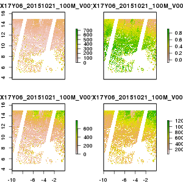

```r
b_vrt_s <- subset(b_vrt,1:4)
plot(b_vrt_s)
```

## Cloudfilter example

"Clouds in satellite observations obstruct the retrieval of vegetation parameters. Therefore a proper cloud screening is pivotal in the pre-processing of the various value-added products. The ProbaV cloud detection algorithm is a modified version of the method applied to the SPOTVGT BLUE and SWIR observations (Lissens et al., 2000). Using these band reflectances, two separate cloud masks are created. The first (second) mask uses a BLUE (SWIR) band threshold with an additional check at 300 m resolution on the SWIR (BLUE) band. The final cloud mask is a merge of these two masking results. Compared to the SPOT-VGT cloud mask, some modifications were necessary, because the assumption that clouds are observed at the same position in both the BLUE and SWIR bands is no longer valid for ProbaV, due to the observation time difference." [source](http://ProbaV.vgt.vito.be/sites/default/files/Product_User_Manual.pdf) p.17.

In addition to the added cloud/shadow algorithm applied on the ProbaV products, the ProbaV R package adds an additional cloud filter which requires some manual interpretation. The following section will visualize the difference between the cloud/shadow algorithm from ProbaV and the created cloud filter function in the ProbaV R package.

We will start of with a false color image of our subset area previous defined by the extent function. We will simply use all bands available. In order to create a false color image, we will have to rerun our probaV::ProccesProbaVbatch without filtering the cloud/shadow pixels.

```r
# Select all the bands for a false color image from the RADIOMETRY stack
bands_select <- '(BLUE|SWIR|NIR0|RED0)'
bands_sel <- paste(bands_select,'_sm.tif$', sep = "")

# run process batch on the unfiltered data
# Here we change the QC_value to select all the cells, including the cloud values.
# Write the clouds to a new directory, so it wont mess up the original file
# Select one point in time, lets say: 2015-10-21

cloud_dir <- "rsdata/ProbaV/sm_Withclouds"
dir.create(file.path(cloud_dir), showWarnings = FALSE)

# select dir with clouds
ProbaV_cloud_dir <- paste(getwd(),'/',cloud_dir, sep = "")
l0_dir1 <- "/data/MTDA/TIFFDERIVED/PROBAV_L3_S5_TOC_100M/20151021"
```

```r
# we wont use NDVI for the cloud filter in this example, just the radiometry is needed
patterns <- c('RADIOMETRY.tif$')
processProbaVbatch(l0_dir1,
                    pattern = patterns, tiles = tiles, start_date = "2015-10-21", end_date = "2015-10-21",
                    QC_val = 1:255, outdir = ProbaV_cloud_dir,
                    ncores = 5,
                    overwrite=F)
```

Rerun the virtual stack function on our newly created directory with unfiltered data. Since we are working with a specific start and end date to visualize a false color image on a fixed time, we adjust our start and end date accordingly. We also set a smaller extent for this tutorial. The smaller the extent (region of interest), the faster the processing. We set the following extent by assigning the x and y coordinates accordingly (lat/lon, WGS84).

```r
# set extent
xmin <- -2.064549
xmax <- -1.074974
ymin <- 8.840184
ymax <- 10.39336

# select directory with clouds (cloud_dir)
ProbaV_cloud_dir <- paste(getwd(),'/',cloud_dir,'/', sep = "")

# create virtual raster output name
vrt_name <- file.path(outdir, paste0(tiles, "_",paste0(bands, collapse = "_"), ".vrt"))

# load the image in our virtual raster stack
# Adding the parameter 'te' allows you to crop the selected images to a user defined extent.
b_vrt_cloud <- timeVrtProbaV(ProbaV_cloud_dir, pattern = bands_sel, vrt_name = vrt_name, tile = tiles, return_raster = T, start_date = "2015-10-21", end_date = "2015-10-21", te = c(xmin,ymin,xmax,ymax))
```

```r
##
##  building main vrt, layers: 4
```

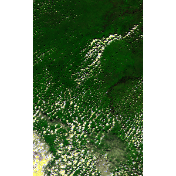

```r
# plot a false color image
plotRGB(b_vrt_cloud, 3, 2, 1, stretch='lin')
```

Well that looks cloudy! Good, now we can start adding the ProbaV cloud mask and the ProbaV R package cloud filter. Lets start with visualizing the cloud detection method in-bedded in the ProbaV data.

```r
# cloud mask SM
bands_select <- '(BLUE|SWIR|NIR0)'
bands_sel <- paste(bands_select,'_sm.tif$', sep = "")

# create virtual raster stack output name
vrt_name <- file.path(paste0(outdir,"/",tiles, "_",paste0(bands_select, collapse = "_"), ".vrt"))

# load the image in our virtual raster stack
b_vrt_cloud_mask <- timeVrtProbaV(ProbaV_sm_dir, pattern = bands_sel, vrt_name = vrt_name, tile = tiles, return_raster = T, start_date = "2015-10-21", end_date = "2015-10-21", te = c(xmin, ymin, xmax, ymax))
```

```r
##
##  building main vrt, layers: 3
```

```r
# assign virtual raster stack to new variable
r <- b_vrt_cloud_mask
```

all NA values in our raster(r) are in this scene cloud pixels. We assign a value (9999) to these cloud pixels in order to visualize them against our cloud filter function later on.

```r
# set NA's
b_vrt_cloud_mask[is.na(r)] <- 9999
b_vrt_cloud_mask[b_vrt_cloud_mask < 9999] <- NA

# subset a single raster band, I will take the BLUE band.
b_vrt_cloud_mask <- subset(b_vrt_cloud_mask,1)
```

Lets plot the original cloud detection method in-bedded within the ProbaV data.

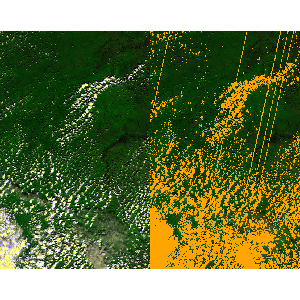

```r
par(mfrow=c(1,2))
plotRGB(b_vrt_cloud, 3, 2, 1, stretch='lin')
plotRGB(b_vrt_cloud, 3, 2, 1, stretch='lin')
plot(b_vrt_cloud_mask, col = 'orange', legend = F, add = T)
```

```r
par(mfrow=c(1,1))
```

Looks good! The orange area here visualizes the clouds/shadow and bad pixels detected by the cloud detection algorithm within ProbaV. If you look closely, you can still observe cloud and shadow remnants, mostly near the orange masked clouds. Although this original cloud detection algorithm already masked out almost all clouds, we would like to clear as many clouds (and shadow) as possible, so we have a clear reflectance of the pixels. Because remaining clouds in remote sensing time-series can impair the extraction of seasonal information.

Lets apply the additional cloud filter! In this example we use the blue band to detect additional cloud and shadow remnants in the landscape. The BlUE and SWIR bands are conventionally sensitive in cloud detection. For our final classification, in the section **Spatial Harmonic Metrics**, we will use both BLUE and SWIR for additional cloud detection and removal.

The cloud_filter function applies the [loess](https://stat.ethz.ch/R-manual/R-devel/library/stats/html/loess.html) through the 'ProbaV::smoothloess' function. Observations where difference to the LOESS model exceeds a threshold are masked as clouds or cloud shadow. The 'ProbaV::smoothloess' function applies a smoothing approach, by fitting a locally weighted scatterplot smoothing model. The threshold values are determined visually, and might require testing to select the optional parameters for cloud detection. If you wish to apply the tutorial on different (eco-)regions, be sure test different thresholds for cloud/shadow detection. The span parameter controls the degree of smoothing. A higher span smooths out the fit more, while a lower span captures more trends but introduces statistical noise if there is too little data (We will test this later).

```r
# select bands and create virtual name output
bands_select <- '(BLUE)'
bands_sel <- paste(bands_select,'_sm.tif$', sep = "")
vrt_name <- file.path(paste0(outdir,"/",tiles, "_",paste0(bands_select, collapse = "_"), ".vrt"))

# Select all dates of the blue band
b_vrt <- timeVrtProbaV(ProbaV_sm_dir, pattern = bands_sel, vrt_name = vrt_name, tile = tiles, return_raster = T, start_date = "2015-10-21", end_date = "2016-03-01", te = c(xmin, ymin, xmax, ymax))
```

```r
##
##  building main vrt, layers: 27
```

```r
# create output folder and name
dir.create('/userdata/cloud_filter', showWarnings = F)
out_name <- paste('/userdata/cloud_filter/cloud_filter.envi', sep = "")
```

The 'cloud_filter' function is an intensive computational and disk volume demanding function, as it returns all the .tif files (as brick) within you 'date' selection. However, since we select a subset by setting an extent in the 'probaV::timeVrtProbaV' function, the output files should not be that big in volume. The 'cloud_filter' is not part of the 'ProbaV' package, but is derived from it. The threshold parameters are similar to existing functions within the 'ProbaV' package. Where:

- x = Virtual stack of .tif files
- ProbaV_sm_dir: Directory containing the processed ProbaV bands as a result of the 'ProcessProbaVBatch'
- pattern: Band selection including the _sm (state mask)
- tiles: tile to process
- minrows: See section on 'setting parameters'
- mc.cores: See section on 'setting parameters'
- logfile: See section on 'setting parameters'
- span: Degree of smoothing
- cf_bands: The selection (numeric) of the bands you would like to use for the cloudfilter function
- Thresholds: The distance (reflectance) values from the smoothloess model to mask as clouds/shadow
- filename: output file name
- ... e.g. overwrite (Default = False)

Minrows and mc.cores should be considered carefully when running the cloud_filter on whole tiles. The settings depend on the available VM specs, such as cores and RAM. We have not yet found a way to deal with this issue effectively. Hence, if you run into errors, try to tune down the 'minrows' or the 'mc.cores' (e.g. minrows = 2 when working on whole tiles).

```r
bands_select <- '(BLUE)'
bands_sel <- paste(bands_select,'_sm.tif$', sep = "")


cloud_filter(x = b_vrt, ProbaV_sm_dir = ProbaV_sm_dir, pattern = bands_sel,
                          tiles = tiles, minrows = minrows, mc.cores = mc.cores,
                          logfile=logfile, overwrite=T, span=0.3,
                          cf_bands = c(1), thresholds=c(-80, Inf),
                          filename = out_name)

blue_c_filter <- brick(out_name)
```

Lets select the same *date* as our false color image from the raster brick we just created. In this case, the first raster subset of our filter.

```r
# select date
blue_c_filter <- subset(blue_c_filter ,1)
```

The 'cloud_filter' function returns the Quality Control values. Meaning: "QC" is the status of observations: 0=Missing/band input QC, 1=good, 2=temporal outlier. Here we assign new values to our raster to visualize what the 'SmoothLoes' function detects on clouds/shadow

```r
# copy the data set
blue_c_filter_copy <- blue_c_filter
# assign values
blue_c_filter[blue_c_filter_copy != 2] <- NA
blue_c_filter[blue_c_filter_copy == 2] <- 1
```

```r
blue_c_filter <- brick(out_name)
blue_c_filter <- subset(blue_c_filter ,1)
# copy the data set
blue_c_filter_copy <- blue_c_filter
# assign values
blue_c_filter[blue_c_filter_copy != 2] <- NA
blue_c_filter[blue_c_filter_copy == 2] <- 1
```

Alright! Now lets plot our cloud filter!

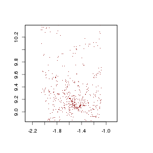

```r
plot(blue_c_filter, col = 'darkred', legend = F)
```

Lets plots the original false color again against the 2 cloud filters

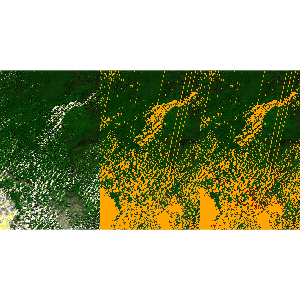

```r
# data copy
r3 <- b_vrt_cloud_mask
# assign pixel values
r3[blue_c_filter == 1] <- 1
# set breakpoints
breakpoints <- c(0,2,9999)
# Assign colors to breakpoints
colors <- c("darkred","orange")
# Set layout
par(mfrow=c(1,3), layout(matrix(1:6, 1,1, byrow = TRUE)))
# Plotting
plotRGB(b_vrt_cloud, 3, 2, 1, stretch='lin')
plotRGB(b_vrt_cloud, 3, 2, 1, stretch='lin')
plot(b_vrt_cloud_mask, col = 'orange', legend = F, add = T)
plotRGB(b_vrt_cloud, 3, 2, 1, stretch='lin')
plot(r3,breaks=breakpoints,col=colors, add = T, legend = F)
```

```r
# Reset layout
par(mfrow=c(1,1))
```

The cloud detection algorithm in-bedded in the ProbaV data detects most of the clouds. The additional 'cloud_filter' marks some clouds/shadow fragments missed by the cloud detection algorithm. As can be observed, these missed cloud pixels are mainly distributed near the edges of existing clouds.

## Time series

Lets start of with creating a small time-series subset of a single pixel, randomly chosen from a raster stack. Since we are interested in the seasonal trends of vegetation, lets select the NDVI band for the following example. First step is to create a virtual raster stack from a selected time range on our region of interest (extent).

```r
# select bands
bands_select <- '(NDVI)'
bands_sel <- paste(bands_select,'_sm.tif$', sep = "")
vrt_name <- file.path(paste0(outdir,"/",tiles, "_",paste0(bands_select, collapse = "_"), ".vrt"))

# Select all dates of the blue band and return it as a raster.
b_vrt <- timeVrtProbaV(ProbaV_sm_dir, pattern = bands_sel, vrt_name = vrt_name, tile = tiles, return_raster = T, start_date = "2014-01-21", end_date = "2016-09-01", te = c(xmin, ymin, xmax, ymax))
```

```r
##
##  building main vrt, layers: 63
```

```r
# Select random pixel of our raster stack
set.seed(42)
z <- zoo(c(b_vrt[runif(1, 0, ncell(b_vrt))]), as.Date(getZ(b_vrt), "%Y%j"))

# read and assign the acquisition dates to a variable (df_ProbaV_sm). Notice that the return_raster variable is set to 'False', and will thus return a dataframe with metadata on the selected dates.
df_ProbaV_sm <- timeVrtProbaV(ProbaV_sm_dir, pattern = bands_sel, vrt_name = vrt_name, tile = tiles[1], return_raster = F, start_date ="2014-01-21", end_date = "2016-09-01", te = c(xmin, ymin, xmax, ymax))
```

```r
##
##  building main vrt, layers: 63
```

Lets apply the smoothLoess function. This function requires a time series [ts](https://stat.ethz.ch/R-manual/R-devel/library/stats/html/ts.html) object. We create one using the [zoo](https://cran.r-project.org/web/packages/zoo/index.html) package. The smoothLoess function uses local polynomial regression fitting, by using the [loess](https://stat.ethz.ch/R-manual/R-devel/library/stats/html/loess.html) function. The smoothLoess function requires the dates to match with the index values, hence we retrieved the matching dates above.

**Smoothloess function**

Observations where difference to the LOESS model exceeds a threshold are masked as clouds or cloud shadow. The 'ProbaV::smoothloess' function applies a smoothing approach, by fitting a locally weighted scatterplot smoothing model. We used this function before in the cloudfilter section of this tutorial. The span parameter controls the degree of smoothing. The higher the span value, the higher the smoothing of a time series object.

The parameters of the 'LOESS' model and the thresholds were chosen based on expert knowledge and visual comparison of the results within the semi-arid region of Africa. These parameters could thus change if you select a different (eco-)regional area, and may require testing and comparing results for optimal parameter selection.

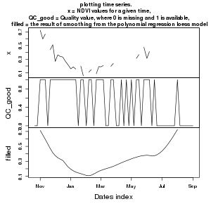

```r
# use smoothloes to create time series

# retrieve band and date information from dataframe
bands <-  df_ProbaV_sm[df_ProbaV_sm$date == df_ProbaV_sm$date[1], 'band']
dates <-  df_ProbaV_sm[df_ProbaV_sm$band == bands[1], 'date']

# We excluded the threshold parameter and simply plot the output of the smoothLoess function.
f <- smoothLoess(tsx = z, QC_good=NULL, dates=dates , res_type=c("all"), span=0.3)
plot(f, main = "plotting time series.
     x = NDVI values for a given time,
     QC_good = Quality value, where 0 is missing and 1 is available,
     filled = the result of smoothing from the polynomial regression loess model", xlab = "Dates index")
```

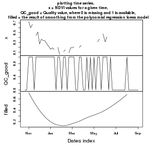

```r
# Observe the difference between span widths of the degree of smoothing.
f <- smoothLoess(tsx = z, QC_good=NULL, dates=dates , res_type=c("all"), span=0.75)
plot(f, main = "plotting time series.
     x = NDVI values for a given time,
     QC_good = Quality value, where 0 is missing and 1 is available,
     filled = the result of smoothing from the polynomial regression loess model", xlab = "Dates index")
```

As can be observed above, smoothing the model by setting a (too) high span value can smooth out vegetation trends which might be important for your classification later on. Altough we plot the 'filled' values here as well, they are not used in the final models. Filling gaps between time observations based on linear models can create a false interpretation of vegetation trends, especially when the time between observations is large (e.g. months).

## Harmonic metrics

Second or Third order harmonics will create an additional output of the Cosine and Sine multiplied the selected order. Higher order harmonics will be added to the lower order harmonics.

Lets show the formula used to calculate the 'cos' and 'sin' values.

k <- (2*pi)

cos <- cos(dates*k) sin <- sin(dates*k)

**formula <- x ~ (co + si) # Here x is an observation through time**

with higher order harmonics, the formula is adjusted by multiplying the cos and sin with the order:

e.g. when order = 2.

co2 <- cos(2*dates*k) si2 <- sin(2*dates*k)

These additional coefficients (co2 and si2) will be added to the formula:

**formula <- x ~ co + si + co2 + si2**

The probaV package currently supports the required 'harmonic order' of atleast 1 to up to 3.

QC-good parameter ensures that reflectance values that are missing (0 or not 1) are omitted (the fitted values are thus **not** used). Reflectance values that are marked as clouds/shadow by the 'probaV::smoothLoess' function (value 2 in QC-good) will be ignored by the linear model.

Lets test the probaV::getHarmMetrics function on our timeseries(z).

```r
# Run the smoothloess function on timeseries (z)
f <- smoothLoess(tsx = z, QC_good=NULL, dates=dates , res_type=c("all"), span=0.3)

# With the return_model = T, we return the harmonic model. Otherwise, it will return the coefficients (metrics)
model_metrics <- getHarmMetrics(f$x,QC_good = f$QC_good ,dates = dates, order = 1, return_model = T)

# return model
model_metrics
```

```r
##
## Call:
## lm(formula = form)
##
## Coefficients:
## (Intercept)           co           si        trend
##    985.0434      -0.2750      -0.1932      -0.4884
```

As previously explained, the number of output coefficients (metrics) depend on the parameter 'order' of harmonics. Lets see the difference in output from different 'order' levels.

```r
# Run the getHarmMetrics function with return_model = F, so we return just the metrics
model_metrics <- getHarmMetrics(f$x,QC_good = f$QC_good ,dates = dates, order = 1, return_model = F)
```

```r
# Order 1
cat("The metrics returned by the getHarmMetrics function, with order 1, are the: ", names(model_metrics))
```

```r
## The metrics returned by the getHarmMetrics function, with order 1, are the:  min max intercept co si trend
```

```r
# Order 2
model_metrics <- getHarmMetrics(f$x,QC_good = f$QC_good ,dates = dates, order = 2)
cat("The metrics returned by the getHarmMetrics function, with order 2, are the: ", names(model_metrics))
```

```r
## The metrics returned by the getHarmMetrics function, with order 2, are the:  min max intercept co si co2 si2 trend
```